# Descriptives III: Exploring stacked data format

# Introduction

Here we will look at the effect of transforming the data by stacking it at the subframe level. We get repeated rows for stories with multiple subframes -the maximum number of mutiple subframes that were coded was 3.

#### Country observations in Framing dataset

| country | N_observations |
| --- | --- |
| UK | 101 |
| Austria | 100 |
| Germany | 100 |
| Greece | 100 |
| Romania | 100 |
| Italy | 99 |
| Spain | 99 |
| France | 93 |

# Stacking the data

Here we examine descriptives after stacking the data. Instead of unique story level rows, the data is now stacked at the subFrame level…up to 3 subframes per story. If all stories had 3 subframes, we would have 2376 observations. But we don’t. That’s because few stories contain multiple subframes.

## Multiple subframes

The wide dataset (unstacked) had 792 observations, the number of observations has been augmented to 1004. This is the country breakdown. Note that non-replicated number of observations per country is around 100 -with some being lower, e.g. France (93) and Spain (99).

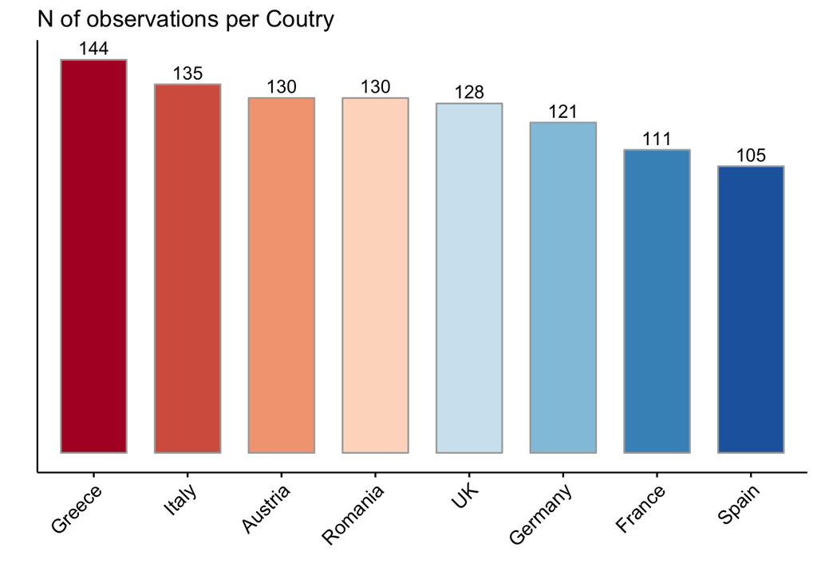

The number of additional subframes for countries is rather low. In same cases, e.g. Spain, there are virtually no additional subframes with ony 6 stories have an additional subframe. Spain, and France, seem to have been coded differently to the rest.

In other words, whereas in most cases around 30% of cases had multiple subframes (and in Greece ~ 44%), in Spain it was only 6 stories (~ 6%).

Let’s check how it affects the main distributions.

## Countries and Regions

Among the most important distributions for the analysis is the Country * Level cell count. The cell count is probably acceptable for regional, improves very marginally.

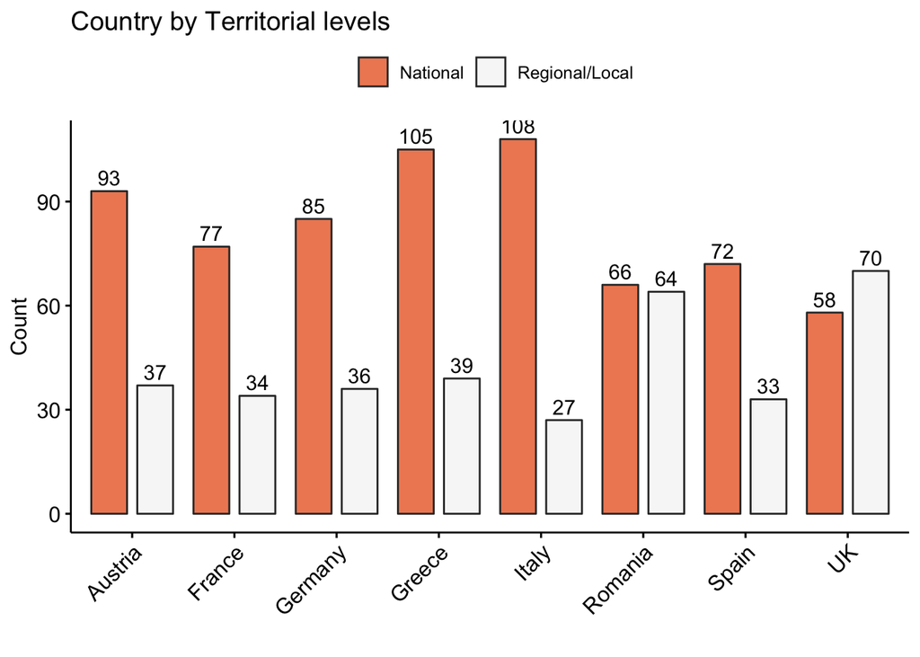

## Dominant dimensions

There’s a slight improvement in the cell count with the stacked format. The cell with the lowest count is Greece regional level for Politics dimension.

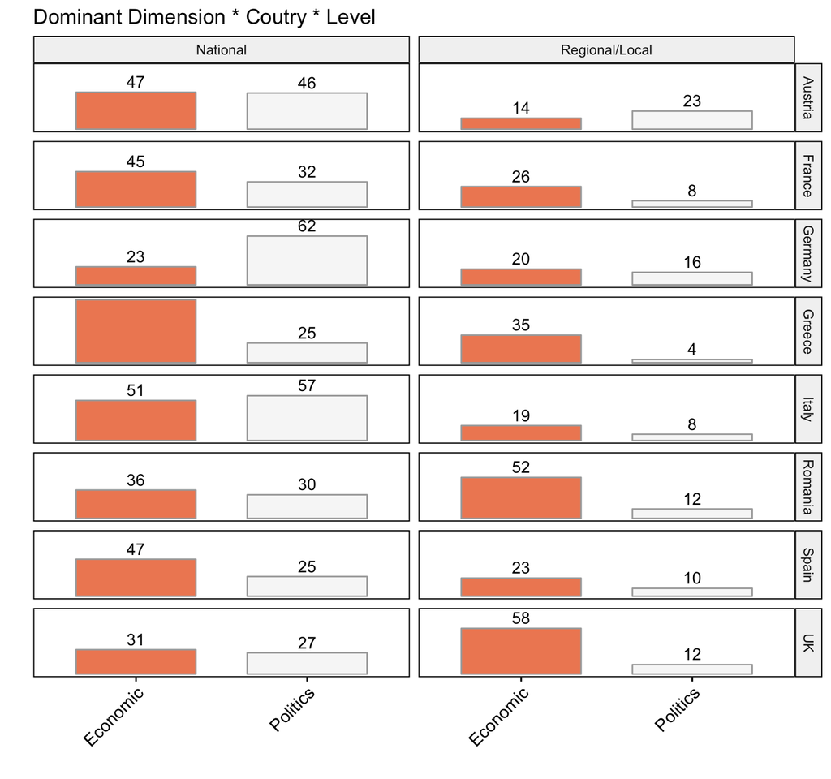

## Tone dimensions

There are some patterns that are visible at the country level * regional level, that will probably come out in the regression.

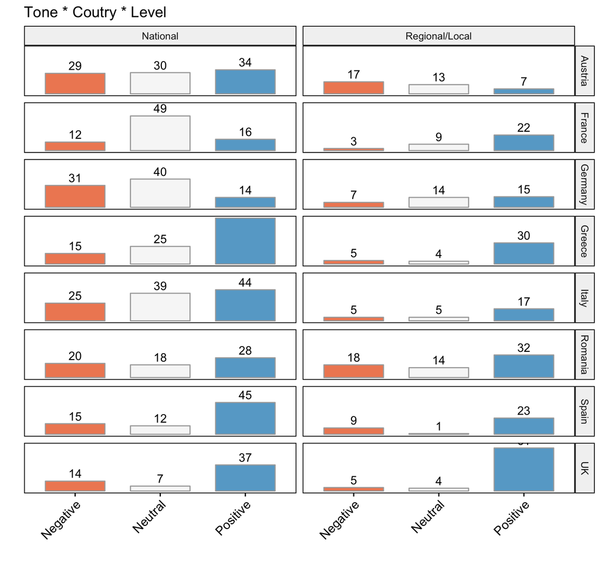

## Tone * Dimension

Here we look at the Tone by overarching dimension. We don’t even need to run a regression to know that the way Frames have been coded/defined drives Tone. Economic frames are overwhelmingly Positve (the blue) whereas Politics frames are largely Negative. The effect is so strong that it is probably true by definition, i.e., by the way in which the terms are defined and coded in practice.

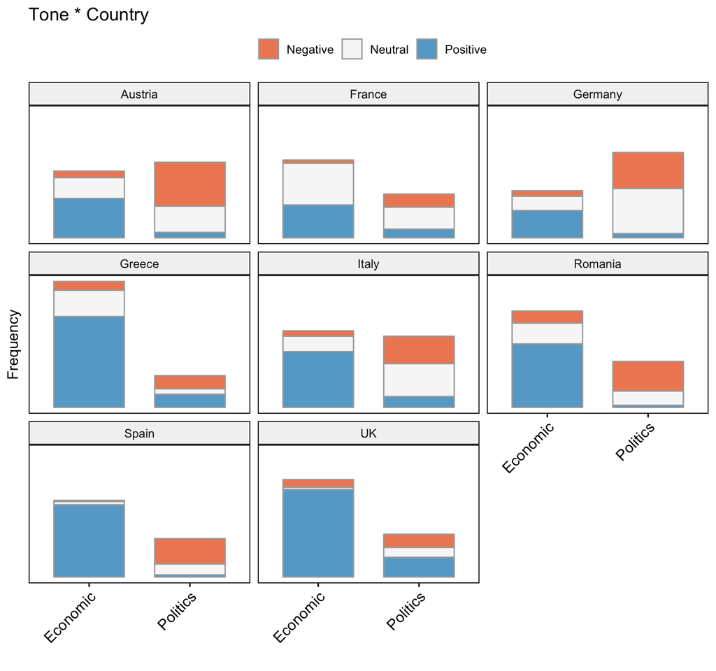

# Summary

The main issue with stacking could be the case of Spain, and to a somewhat lesser extent France.